# Logistic regression

Anna-Liina Olkinuora

9 helmikuuta 2017

En saanut vietyä tätä tiedostoa Github-päiväkirjaan. Julkaisin sen R:n palvelun kautta, toivottavasti tehtäväni voidaan hyväksyä. pp

```r
alc=read.table("data/alc.txt", sep = ",", header = TRUE)

head(alc)
```

```
##   school sex age address famsize Pstatus Medu Fedu     Mjob     Fjob
## 1     GP   F  18       U     GT3       A    4    4  at_home  teacher
## 2     GP   F  17       U     GT3       T    1    1  at_home    other
## 3     GP   F  15       U     LE3       T    1    1  at_home    other
## 4     GP   F  15       U     GT3       T    4    2   health services
## 5     GP   F  16       U     GT3       T    3    3    other    other
## 6     GP   M  16       U     LE3       T    4    3 services    other
##       reason nursery internet guardian traveltime studytime failures
## 1     course     yes       no   mother          2         2        0
## 2     course      no      yes   father          1         2        0
## 3      other     yes      yes   mother          1         2        2
## 4       home     yes      yes   mother          1         3        0
## 5       home     yes       no   father          1         2        0
## 6 reputation     yes      yes   mother          1         2        0
##   schoolsup famsup paid activities higher romantic famrel freetime goout
## 1       yes     no   no         no    yes       no      4        3     4
## 2        no    yes   no         no    yes       no      5        3     3
## 3       yes     no  yes         no    yes       no      4        3     2
## 4        no    yes  yes        yes    yes      yes      3        2     2
## 5        no    yes  yes         no    yes       no      4        3     2
## 6        no    yes  yes        yes    yes       no      5        4     2
##   Dalc Walc health absences G1 G2 G3 alc_use high_use
## 1    1    1      3        5  2  8  8     1.0    FALSE
## 2    1    1      3        3  7  8  8     1.0    FALSE
## 3    2    3      3        8 10 10 11     2.5     TRUE
## 4    1    1      5        1 14 14 14     1.0    FALSE
## 5    1    2      5        2  8 12 12     1.5    FALSE
## 6    1    2      5        8 14 14 14     1.5    FALSE
```

```r
attach(alc)
```

Aineiston muuttujia ovat esimerkiksi alkoholin käyttö viikolla, alkoholin käyttö viikonloppuna, terveys, poissaolot, alkoholin käyttö koko viikon aikana, suuri alkoholinkulutus, opiskeluun käytetty aika, huoltaja, perheen koko, osoite, ikä, sukupuoli ja koulu. Siinä oli vain osa muuttujista. Loput näkyvät tulosteesta.

Tutkin seuraavaksi suuren alkoholinkäytön joka on looginen muuttuja yhteyttä terveyteen, poissaoloihin, opiskeluun käytettyyn aikaan ja sukupuoleen. Hypoteesini on että terveys ja suuri alkoholinkäyttö korreloivat negatiivisesti. Arvioin myös että opiskeluun käytetyllä ajalla ja suurella alkoholinkäytöllä on negatiivinen korrelaatio. Arvioin myös että poissaolot ja suuri alkoholinkäyttö korreloivat positiivisesti. Hypoteesini on että sukupuoli vaikuttaa suureen alkoholinkäyttöön niin että miehissä on enemmän heitä jotka käyttävät paljon alkoholia eli heitä joille high_use-muuttuja saa arvon TRUE.

```r
table(health,high_use)
```

```
##       high_use
## health FALSE TRUE
##      1    35   11
##      2    28   16
##      3    62   19
##      4    49   18
##      5    94   50
```

```r
table(absences,high_use)
```

```
##         high_use
## absences FALSE TRUE
##       0     52   13
##       1     38   13
##       2     42   16
##       3     33    8
##       4     24   12
##       5     16    6
##       6     16    5
##       7      9    3
##       8     14    6
##       9      6    6
##       10     5    2
##       11     2    4
##       12     4    4
##       13     1    1
##       14     1    6
##       16     0    1
##       17     0    1
##       18     1    1
##       19     0    1
##       20     2    0
##       21     1    1
##       26     0    1
##       27     0    1
##       29     0    1
##       44     0    1
##       45     1    0
```

```r
table(studytime,high_use)
```

```
##          high_use
## studytime FALSE TRUE
##         1    58   42
##         2   135   60
##         3    52    8
##         4    23    4
```

```r
table(sex,high_use)
```

```
##    high_use
## sex FALSE TRUE
##   F   156   42
##   M   112   72
```

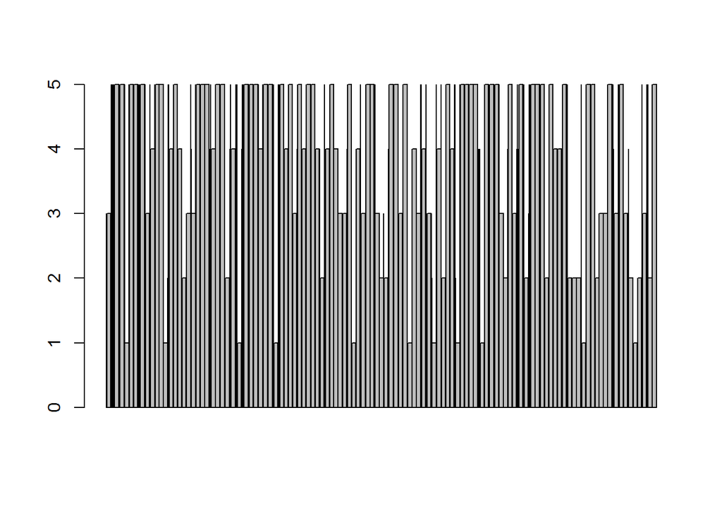

```r
barplot(health,high_use)
```

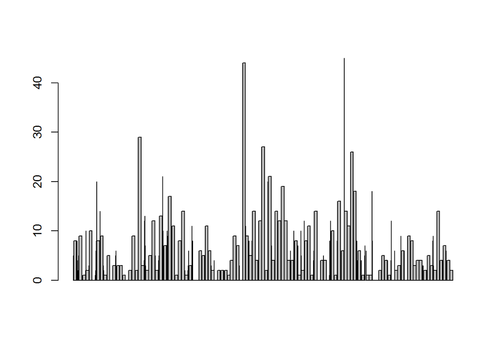

```r
barplot(absences,high_use)
```

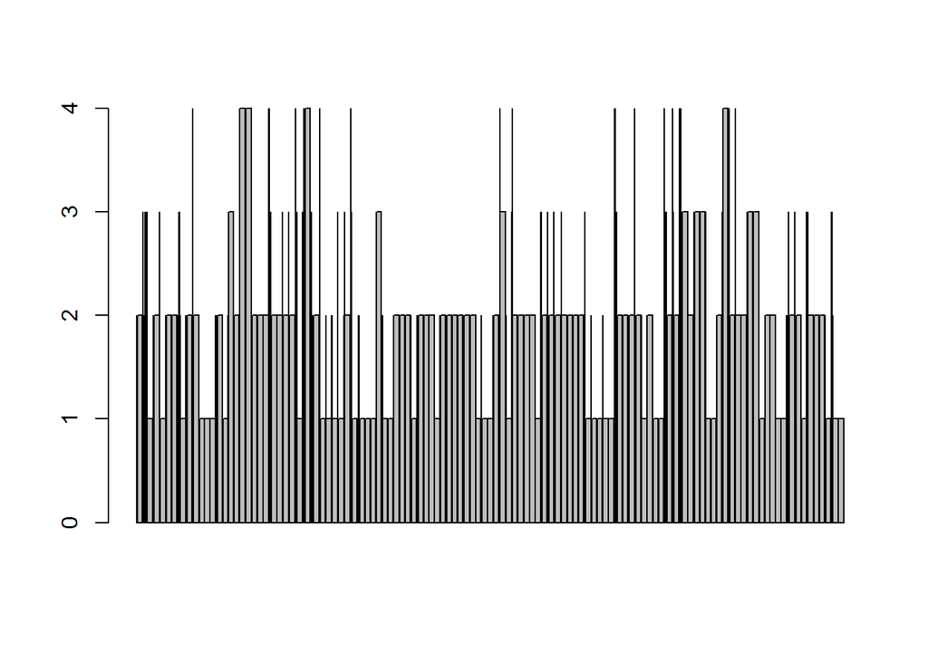

```r
barplot(studytime,high_use)
```

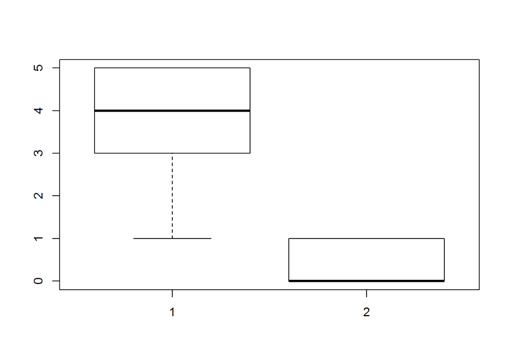

```r
boxplot(health,high_use)
```

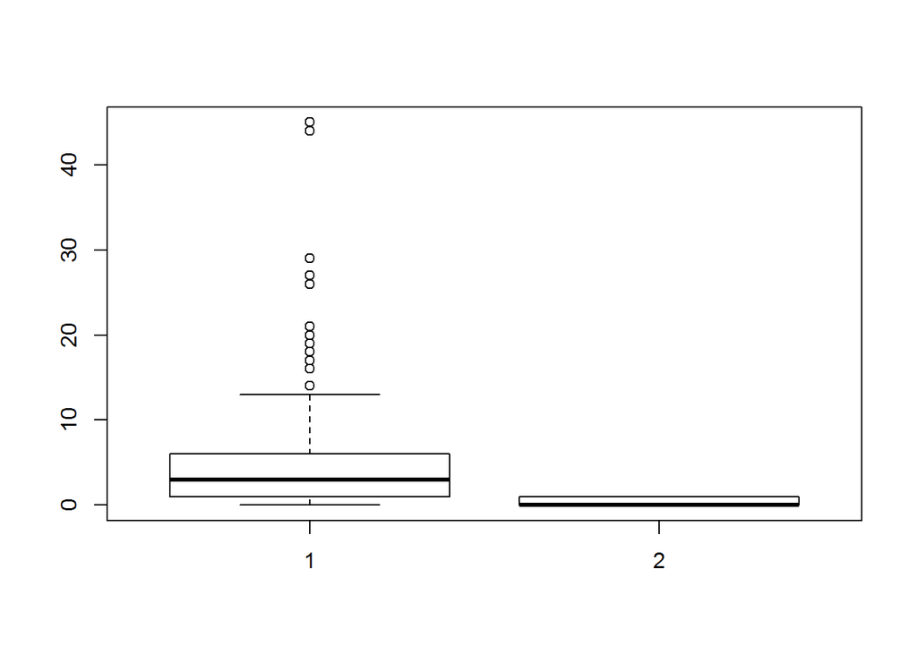

```r
boxplot(absences,high_use)
```

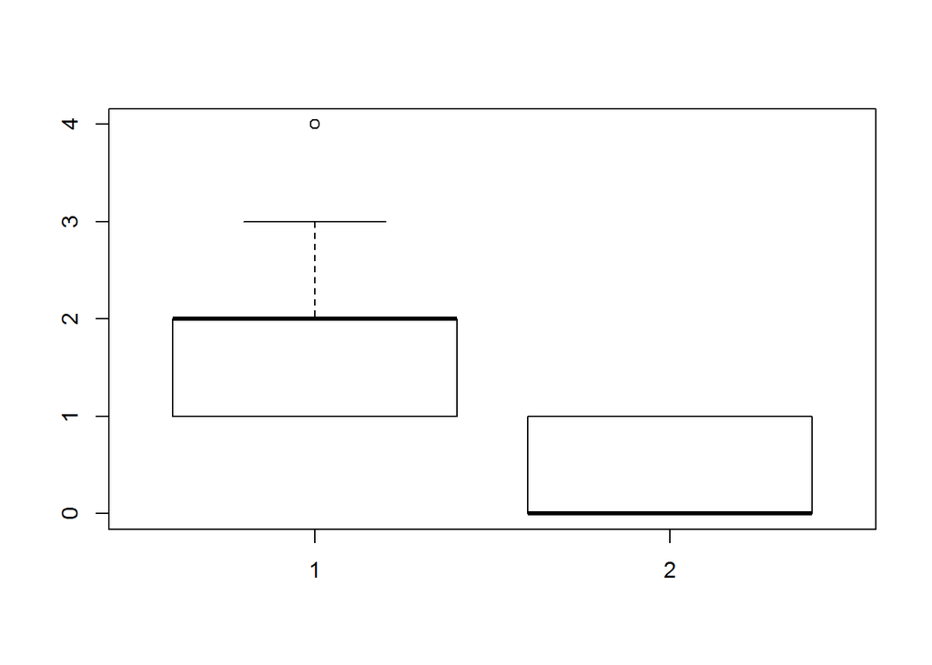

```r
boxplot(studytime,high_use)
```

```r
m = glm(high_use ~ health + absences + studytime + sex, data = alc, family = "binomial")

summary(m)
```

```
##
## Call:
## glm(formula = high_use ~ health + absences + studytime + sex,
##     family = "binomial", data = alc)
##
## Deviance Residuals:
##     Min       1Q   Median       3Q      Max
## -2.2074  -0.8367  -0.5983   1.0910   2.1407
##
## Coefficients:
##             Estimate Std. Error z value Pr(>|z|)
## (Intercept) -1.08010    0.52055  -2.075 0.037995 *
## health       0.04493    0.08631   0.521 0.602675
## absences     0.08881    0.02307   3.850 0.000118 ***
## studytime   -0.39817    0.15960  -2.495 0.012603 *
## sexM         0.78234    0.25261   3.097 0.001954 **
## ---
## Signif. codes:  0 '***' 0.001 '**' 0.01 '*' 0.05 '.' 0.1 ' ' 1
##
## (Dispersion parameter for binomial family taken to be 1)
##
##     Null deviance: 465.68  on 381  degrees of freedom
## Residual deviance: 423.00  on 377  degrees of freedom
## AIC: 433
##
## Number of Fisher Scoring iterations: 4
```